# In class exericse 06

Time series

Frostbear https://sg.linkedin.com/in/farahfoo (SMU Masters in IT business (Fintech and Analytics))https://scis.smu.edu.sg/master-it-business  
2022-03-22

# Tableau Exercise

This link has many data sources suitable for time-series [CEIC data base](https://insights.ceicdata.com/)

Tableau pivot function is equivalent to the R Dplyr ::pivotlong

## 1) View my Tableau dashboard [here](https://public.tableau.com/app/profile/frostbear/viz/SingaporetouristsArrivalsbyAir-Timeseriescycleplot/Dashboard1?publish=yes) to see the Singapore tourists arrivals by air from 2010 to 2019.

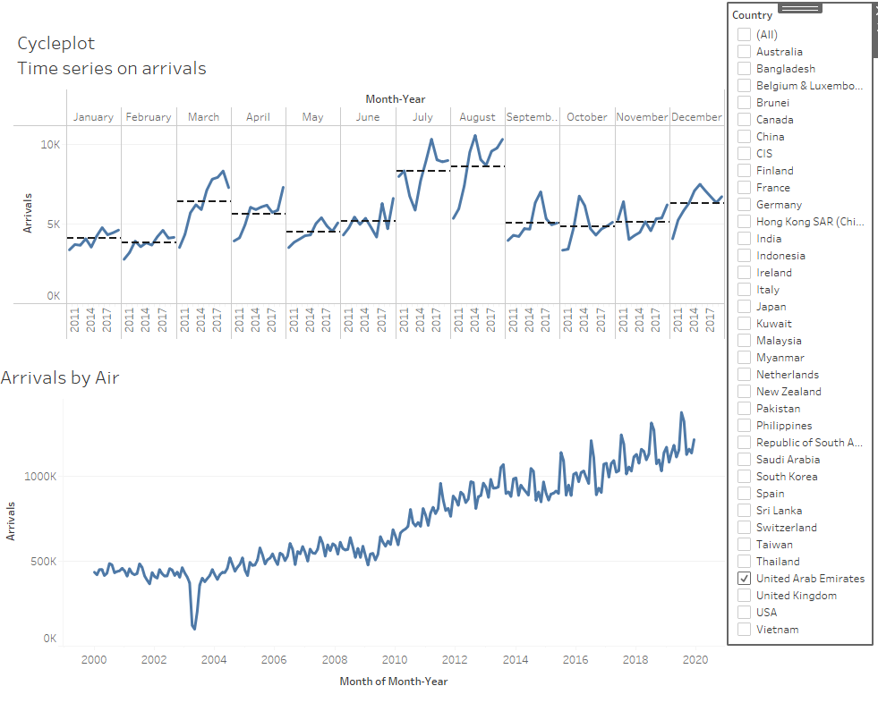

Snapshot

## 2) View my Tableau dashboard [here](https://public.tableau.com/app/profile/frostbear/viz/D05stockpriceincandlestickformat/D05?publish=yes) to see the DBS (D05) stock price chart plotted in Tableau candle stick format.

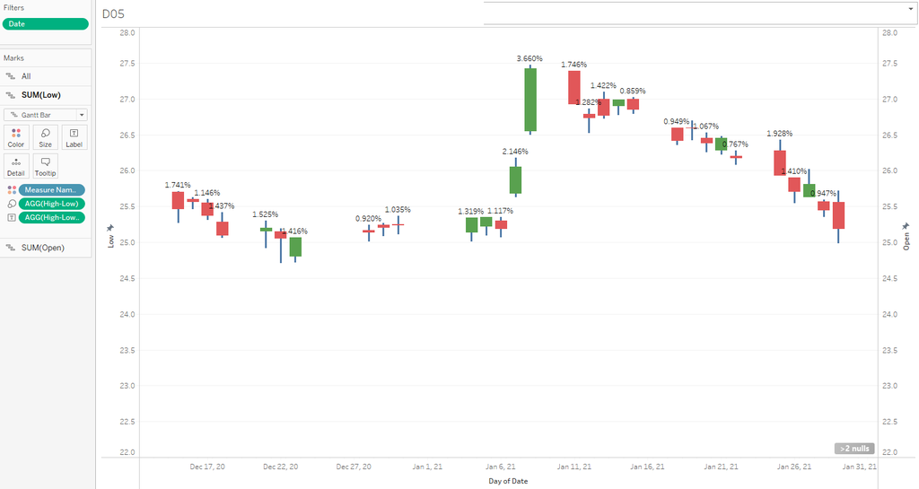

## 3) View my Tableau dashboard [here](https://public.tableau.com/app/profile/frostbear/viz/Cyberattackheatmap/Numberofcyberattacksheatmap?publish=yes) to see the heatmap of cyber attacks.

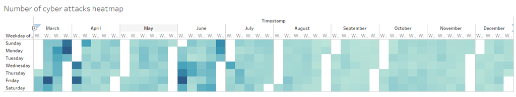

Snapshot

# R EXERCISE

## To load packages required today:

```r
packages = c('scales', 'viridis', 'lubridate', 'ggthemes', 'gridExtra',
             'tidyverse', 'readxl', 'knitr', 'data.table')

for(p in packages){
  if(!require(p, character.only = T)){
    install.packages(p)
  }
  library(p, character.only = T)
}
```

## Loading in excel data

```r
attacks <- read_csv("data/eventlog.csv")

kable(head(attacks))
```

| timestamp | source_country | tz |
| --- | --- | --- |
| 2015-03-12 15:59:16 | CN | Asia/Shanghai |
| 2015-03-12 16:00:48 | FR | Europe/Paris |
| 2015-03-12 16:02:26 | CN | Asia/Shanghai |
| 2015-03-12 16:02:38 | US | America/Chicago |
| 2015-03-12 16:03:22 | CN | Asia/Shanghai |
| 2015-03-12 16:03:45 | CN | Asia/Shanghai |

## Use lubridate to convert the time according to the zone and then extract out the day month year

```r
make_hr_wkday <- function(ts, sc, tz) {
  real_times <- ymd_hms(ts,
                        tz = tz[1],
                        quiet = TRUE)
  dt <- data.table(source_country = sc,
                   wkday = weekdays(real_times),
                   hour = hour(real_times))
  return(dt)
}
```

## Inserting the weekday level for us to use it to organise and control the sorting

Group by the timezone to count the events. Use levels to sequence the days by the predefined sequence wkday. Also convert into factor to allow counting.

```r
wkday_levels <- c('Sunday', 'Monday',
                  'Tuesday', 'Wednesday',
                  'Thursday', 'Friday',
                  'Saturday')
attacks <- attacks %>%
  group_by(tz) %>%
  do(make_hr_wkday(.$timestamp,
                   .$source_country,
                   .$tz ) ) %>%
  ungroup() %>%
  mutate(wkday = factor(wkday,
                        levels = wkday_levels),
         hour  = factor(hour,
                        levels = 0:23))

head (attacks, 5)
```

```
# A tibble: 5 x 4
  tz           source_country wkday    hour
  <chr>        <chr>          <fct>    <fct>
1 Africa/Cairo BG             Saturday 20
2 Africa/Cairo TW             Sunday   6
3 Africa/Cairo TW             Sunday   8
4 Africa/Cairo CN             Sunday   11
5 Africa/Cairo US             Sunday   15
```

## Plotting the headmap by weekday and time

Use geom_tile to plot heatmap. Viridis is a colour scheme

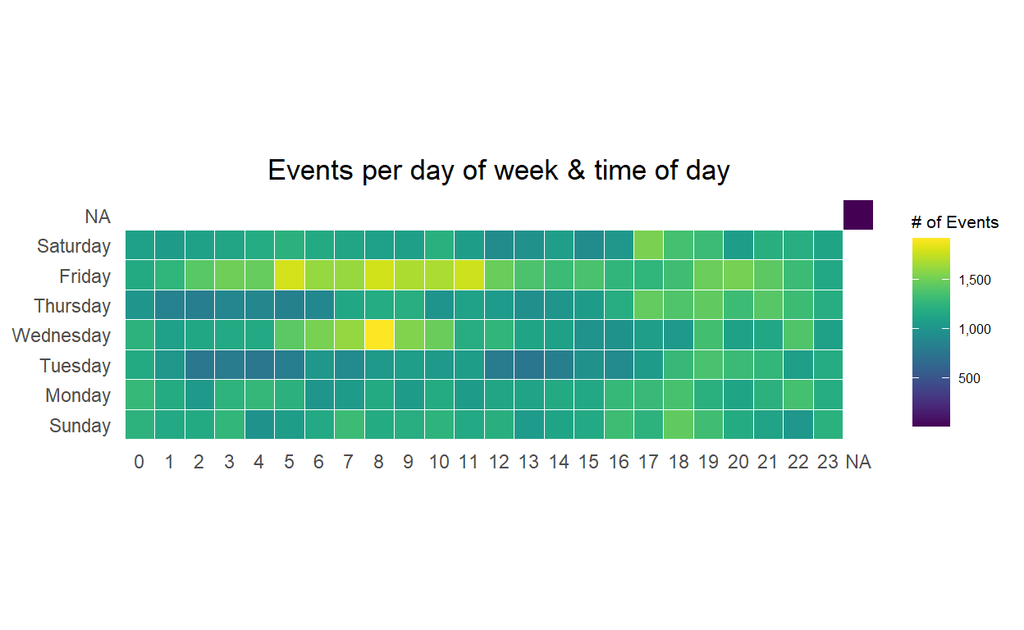

```r
# This is to pull some data/ counting required, after finishing, ungroup the data to reuse later on.

grouped <- attacks %>%
  count(wkday, hour) %>%
  ungroup()


ggplot(grouped, aes(hour, wkday, fill = n)) +
geom_tile(color = "white", size = 0.1) +
theme_tufte(base_family = "Helvetica") +
coord_equal() +
scale_fill_viridis(name = "# of Events", label = comma) +
labs(x = NULL, y = NULL,
     title = "Events per day of week & time of day") +

theme(axis.ticks = element_blank(),
      plot.title = element_text(hjust = 0.5),
      legend.title = element_text(size = 8),
      legend.text = element_text(size = 6) )
```

## Doing cycleplot in R on Singapore arrivals by air

```r
air <- read_excel("data/arrivals_by_air.xlsx")
```

From the existing field month-year, using lubriate month and year function to pull out the year and month into 2 new columns. Set the numbers to factors as 1 to 12 and label the labels as the month abbreviation.

```r
air$month <- factor(month(air$`Month-Year`),
                    levels=1:12,
                    labels=month.abb,
                    ordered=TRUE)

#ymd tells lubridate this is the existing format of data in month-year

air$year <- year(ymd(air$`Month-Year`))

colnames(air)
```

```
 [1] "Month-Year"               "Republic of South Africa"
 [3] "Canada"                   "USA"
 [5] "Bangladesh"               "Brunei"
 [7] "China"                    "Hong Kong SAR (China)"
 [9] "India"                    "Indonesia"
[11] "Japan"                    "South Korea"
[13] "Kuwait"                   "Malaysia"
[15] "Myanmar"                  "Pakistan"
[17] "Philippines"              "Saudi Arabia"
[19] "Sri Lanka"                "Taiwan"
[21] "Thailand"                 "United Arab Emirates"
[23] "Vietnam"                  "Belgium & Luxembourg"
[25] "CIS"                      "Finland"
[27] "France"                   "Germany"
[29] "Ireland"                  "Italy"
[31] "Netherlands"              "Spain"
[33] "Switzerland"              "United Kingdom"
[35] "Australia"                "New Zealand"
[37] "month"                    "year"
```

Extract the country you want, the month and the year for cycle plot

```r
New_Zealand <- air %>%
  select(`New Zealand`,
         month,
         year) %>%
  filter(year >= 2010)
```

The reference line needs to be calculated, add a hline using the mean.

```r
hline.data <- New_Zealand %>%
  group_by(month) %>%
  summarise(avgvalue = mean(`New Zealand`)) %>%
  ungroup()
```

## Cycle plot

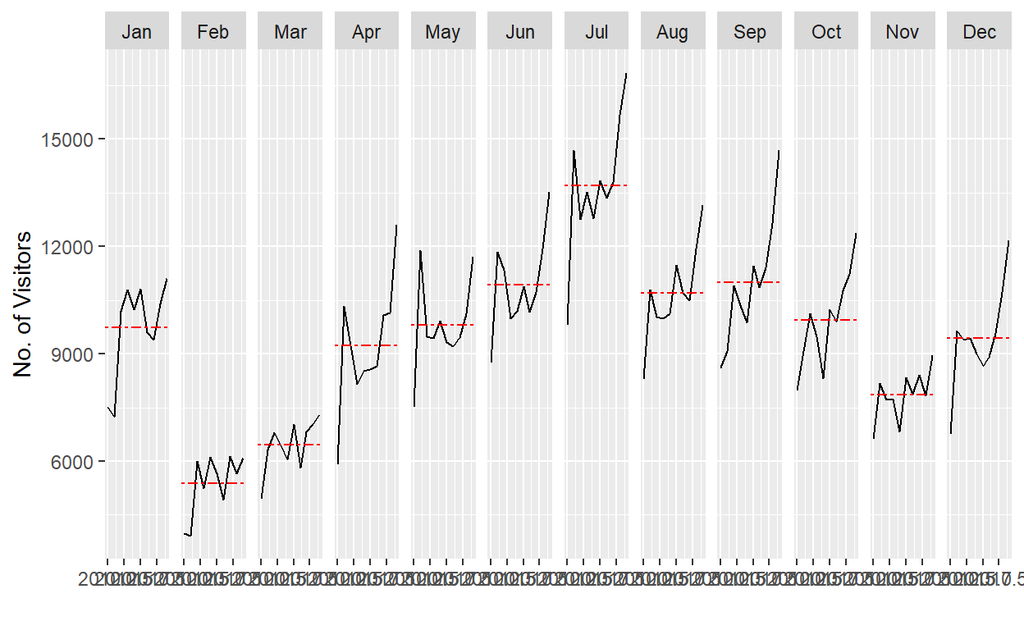

```r
ggplot() +
  geom_line(data=New_Zealand, aes(x=year, y=`New Zealand`, group=month),
            colour="black") +
  geom_hline(aes(yintercept=avgvalue),
             data=hline.data, linetype=6, colour="red", size=0.5) +
  facet_grid(~month) +
  labs(axis.text.x = element_blank()) +
  xlab("") +
  ylab("No. of Visitors")
```

Compare with the one done using Tableau [here](https://public.tableau.com/app/profile/frostbear/viz/SingaporetouristsArrivalsbyAir-Timeseriescycleplot/Dashboard1?publish=yes)

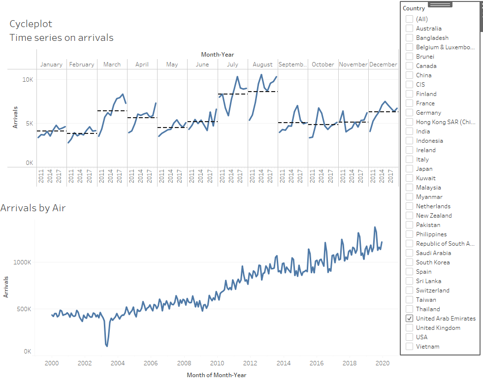